# Untitled-1

```python
import pandas as pd
import numpy as np
import matplotlib.pyplot as plt
import seaborn as sns
import keras
from sklearn.model_selection import train_test_split
from sklearn.preprocessing import StandardScaler
from sklearn.svm import SVC
from sklearn.metrics import accuracy_score, confusion_matrix, classification_report, ConfusionMatrixDisplay
from keras.datasets import mnist
from keras.models import Sequential
from sklearn.model_selection import GridSearchCV
from sklearn.neural_network import MLPClassifier
from keras.layers import Dense, Dropout, Activation, Flatten, Conv2D, MaxPooling2D, BatchNormalization
from keras.layers import Dense, Dropout, Flatten
from keras.layers import Conv2D, MaxPooling2D
from keras import backend as K
from keras.optimizers import Adam
```

```python
df = pd.read_csv(r'C:\Users\ayaYM\Downloads\heart-2.csv')
```

```python
print(df.head())
print(df.info())
print(df.describe())
```

```
   age  sex  cp  trestbps  chol  fbs  restecg  thalach  exang  oldpeak  slope  \
0   52    1   0       125   212    0        1      168      0      1.0      2
1   53    1   0       140   203    1        0      155      1      3.1      0
2   70    1   0       145   174    0        1      125      1      2.6      0
3   61    1   0       148   203    0        1      161      0      0.0      2
4   62    0   0       138   294    1        1      106      0      1.9      1

   ca  thal  target
0   2     3       0
1   0     3       0
2   0     3       0
3   1     3       0
4   3     2       0
<class 'pandas.core.frame.DataFrame'>
RangeIndex: 1025 entries, 0 to 1024
Data columns (total 14 columns):
 #   Column    Non-Null Count  Dtype
---  ------    --------------  -----
 0   age       1025 non-null   int64
 1   sex       1025 non-null   int64
 2   cp        1025 non-null   int64
 3   trestbps  1025 non-null   int64
 4   chol      1025 non-null   int64
 5   fbs       1025 non-null   int64
 6   restecg   1025 non-null   int64
 7   thalach   1025 non-null   int64
 8   exang     1025 non-null   int64
 9   oldpeak   1025 non-null   float64
 10  slope     1025 non-null   int64
 11  ca        1025 non-null   int64
 12  thal      1025 non-null   int64
 13  target    1025 non-null   int64
dtypes: float64(1), int64(13)
memory usage: 112.2 KB
None
               age          sex           cp     trestbps        chol  \
count  1025.000000  1025.000000  1025.000000  1025.000000  1025.00000
mean     54.434146     0.695610     0.942439   131.611707   246.00000
std       9.072290     0.460373     1.029641    17.516718    51.59251
min      29.000000     0.000000     0.000000    94.000000   126.00000
```

[output cut: 9 more lines]

```
min       0.000000     0.000000    71.000000     0.000000     0.000000
25%       0.000000     0.000000   132.000000     0.000000     0.000000
50%       0.000000     1.000000   152.000000     0.000000     0.800000
75%       0.000000     1.000000   166.000000     1.000000     1.800000
max       1.000000     2.000000   202.000000     1.000000     6.200000

             slope           ca         thal       target
count  1025.000000  1025.000000  1025.000000  1025.000000
mean      1.385366     0.754146     2.323902     0.513171
std       0.617755     1.030798     0.620660     0.500070
min       0.000000     0.000000     0.000000     0.000000
25%       1.000000     0.000000     2.000000     0.000000
50%       1.000000     0.000000     2.000000     1.000000
75%       2.000000     1.000000     3.000000     1.000000
max       2.000000     4.000000     3.000000     1.000000
```

```python
print(df.shape)
```

```
(1025, 14)
```

```python
df.head(15)
```

|  | age | sex | cp | trestbps | chol | fbs | restecg | thalach | exang | oldpeak | slope | ca | thal | target |
| --- | --- | --- | --- | --- | --- | --- | --- | --- | --- | --- | --- | --- | --- | --- |
| 0 | 52 | 1 | 0 | 125 | 212 | 0 | 1 | 168 | 0 | 1.0 | 2 | 2 | 3 | 0 |
| 1 | 53 | 1 | 0 | 140 | 203 | 1 | 0 | 155 | 1 | 3.1 | 0 | 0 | 3 | 0 |
| 2 | 70 | 1 | 0 | 145 | 174 | 0 | 1 | 125 | 1 | 2.6 | 0 | 0 | 3 | 0 |
| 3 | 61 | 1 | 0 | 148 | 203 | 0 | 1 | 161 | 0 | 0.0 | 2 | 1 | 3 | 0 |
| 4 | 62 | 0 | 0 | 138 | 294 | 1 | 1 | 106 | 0 | 1.9 | 1 | 3 | 2 | 0 |
| 5 | 58 | 0 | 0 | 100 | 248 | 0 | 0 | 122 | 0 | 1.0 | 1 | 0 | 2 | 1 |
| 6 | 58 | 1 | 0 | 114 | 318 | 0 | 2 | 140 | 0 | 4.4 | 0 | 3 | 1 | 0 |
| 7 | 55 | 1 | 0 | 160 | 289 | 0 | 0 | 145 | 1 | 0.8 | 1 | 1 | 3 | 0 |
| 8 | 46 | 1 | 0 | 120 | 249 | 0 | 0 | 144 | 0 | 0.8 | 2 | 0 | 3 | 0 |
| 9 | 54 | 1 | 0 | 122 | 286 | 0 | 0 | 116 | 1 | 3.2 | 1 | 2 | 2 | 0 |
| 10 | 71 | 0 | 0 | 112 | 149 | 0 | 1 | 125 | 0 | 1.6 | 1 | 0 | 2 | 1 |
| 11 | 43 | 0 | 0 | 132 | 341 | 1 | 0 | 136 | 1 | 3.0 | 1 | 0 | 3 | 0 |
| 12 | 34 | 0 | 1 | 118 | 210 | 0 | 1 | 192 | 0 | 0.7 | 2 | 0 | 2 | 1 |
| 13 | 51 | 1 | 0 | 140 | 298 | 0 | 1 | 122 | 1 | 4.2 | 1 | 3 | 3 | 0 |
| 14 | 52 | 1 | 0 | 128 | 204 | 1 | 1 | 156 | 1 | 1.0 | 1 | 0 | 0 | 0 |

```python
df.describe()
```

|  | age | sex | cp | trestbps | chol | fbs | restecg | thalach | exang | oldpeak | slope | ca | thal | target |
| --- | --- | --- | --- | --- | --- | --- | --- | --- | --- | --- | --- | --- | --- | --- |
| count | 1025.000000 | 1025.000000 | 1025.000000 | 1025.000000 | 1025.00000 | 1025.000000 | 1025.000000 | 1025.000000 | 1025.000000 | 1025.000000 | 1025.000000 | 1025.000000 | 1025.000000 | 1025.000000 |
| mean | 54.434146 | 0.695610 | 0.942439 | 131.611707 | 246.00000 | 0.149268 | 0.529756 | 149.114146 | 0.336585 | 1.071512 | 1.385366 | 0.754146 | 2.323902 | 0.513171 |
| std | 9.072290 | 0.460373 | 1.029641 | 17.516718 | 51.59251 | 0.356527 | 0.527878 | 23.005724 | 0.472772 | 1.175053 | 0.617755 | 1.030798 | 0.620660 | 0.500070 |
| min | 29.000000 | 0.000000 | 0.000000 | 94.000000 | 126.00000 | 0.000000 | 0.000000 | 71.000000 | 0.000000 | 0.000000 | 0.000000 | 0.000000 | 0.000000 | 0.000000 |
| 25% | 48.000000 | 0.000000 | 0.000000 | 120.000000 | 211.00000 | 0.000000 | 0.000000 | 132.000000 | 0.000000 | 0.000000 | 1.000000 | 0.000000 | 2.000000 | 0.000000 |
| 50% | 56.000000 | 1.000000 | 1.000000 | 130.000000 | 240.00000 | 0.000000 | 1.000000 | 152.000000 | 0.000000 | 0.800000 | 1.000000 | 0.000000 | 2.000000 | 1.000000 |
| 75% | 61.000000 | 1.000000 | 2.000000 | 140.000000 | 275.00000 | 0.000000 | 1.000000 | 166.000000 | 1.000000 | 1.800000 | 2.000000 | 1.000000 | 3.000000 | 1.000000 |
| max | 77.000000 | 1.000000 | 3.000000 | 200.000000 | 564.00000 | 1.000000 | 2.000000 | 202.000000 | 1.000000 | 6.200000 | 2.000000 | 4.000000 | 3.000000 | 1.000000 |

```python
df.isnull().sum()
```

```
age         0
sex         0
cp          0
trestbps    0
chol        0
fbs         0
restecg     0
thalach     0
exang       0
oldpeak     0
slope       0
ca          0
thal        0
target      0
dtype: int64
```

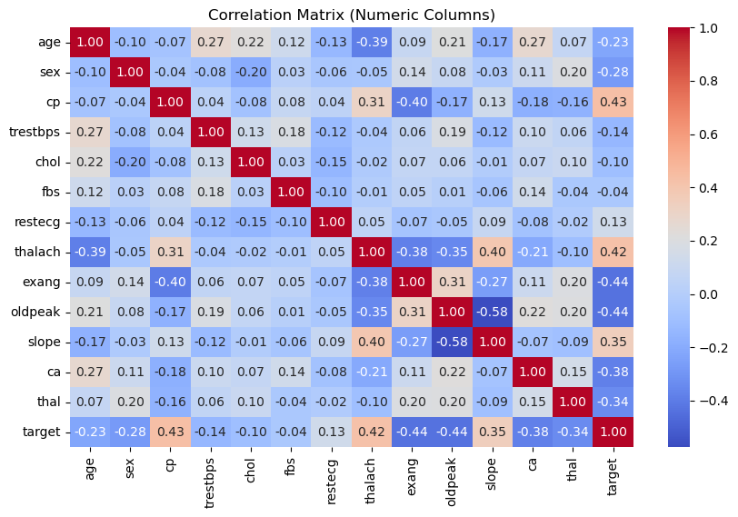

```python
plt.figure(figsize=(10, 6))
sns.heatmap(df.select_dtypes(include=['number']).corr(),
            annot=True, cmap='coolwarm', fmt=".2f")
plt.title("Correlation Matrix (Numeric Columns)")
plt.show()
```

```python
X = df.drop('target', axis=1)  # Features
y = df['target']               # Target

X_train, X_test, y_train, y_test = train_test_split(X, y,test_size=0.3,random_state=42, stratify=y)
```

```python
scaler = StandardScaler()
X_train_scaled = scaler.fit_transform(X_train)
X_test_scaled = scaler.transform(X_test)
```

```python
print(df['target'].value_counts())
```

```
target
1    526
0    499
Name: count, dtype: int64
```

```python
df.info()
```

```
<class 'pandas.core.frame.DataFrame'>
RangeIndex: 1025 entries, 0 to 1024
Data columns (total 14 columns):
 #   Column    Non-Null Count  Dtype
---  ------    --------------  -----
 0   age       1025 non-null   int64
 1   sex       1025 non-null   int64
 2   cp        1025 non-null   int64
 3   trestbps  1025 non-null   int64
 4   chol      1025 non-null   int64
 5   fbs       1025 non-null   int64
 6   restecg   1025 non-null   int64
 7   thalach   1025 non-null   int64
 8   exang     1025 non-null   int64
 9   oldpeak   1025 non-null   float64
 10  slope     1025 non-null   int64
 11  ca        1025 non-null   int64
 12  thal      1025 non-null   int64
 13  target    1025 non-null   int64
dtypes: float64(1), int64(13)
memory usage: 112.2 KB
```

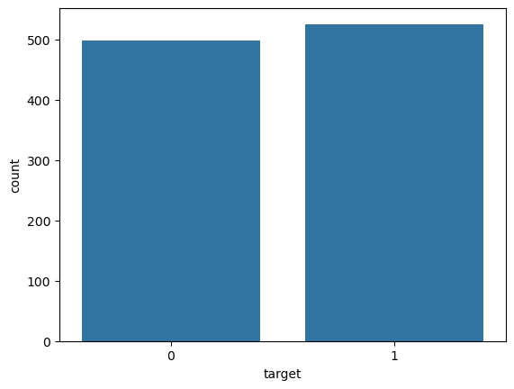

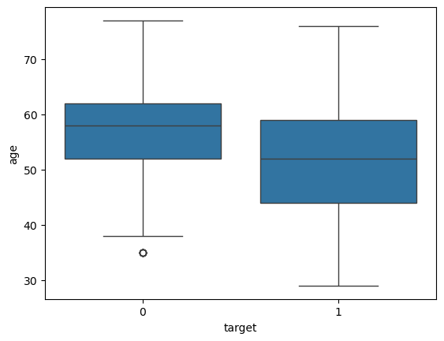

```python
sns.countplot(x='target', data=df)
plt.show()

# Example boxplot for age vs target
sns.boxplot(x='target', y='age', data=df)
plt.show()
```

SVM models

```python
svm_models = {
    "SVC (RBF kernel)": SVC(kernel='rbf', random_state=42),
    "Linear SVM": SVC(kernel='linear', random_state=42),
    "Polynomial SVM": SVC(kernel='poly', degree=3, random_state=42)
}

# Train, predict, and evaluate each model
for name, model in svm_models.items():
    print(f"\n--- {name} ---")

    # Train
    model.fit(X_train_scaled, y_train)

    # Predict
    y_pred = model.predict(X_test_scaled)

    # Accuracy
    acc = accuracy_score(y_test, y_pred)
    print(f"Accuracy on test set: {acc:.4f}")
```

```
--- SVC (RBF kernel) ---
Accuracy on test set: 0.9058

--- Linear SVM ---
Accuracy on test set: 0.8474

--- Polynomial SVM ---
Accuracy on test set: 0.9123
```

```
SVC (RBF kernel) → 90.6% accuracy
The RBF (Radial Basis Function) kernel performs very well on this dataset.
This suggests the decision boundary is nonlinear, and RBF can model it better than a straight line.

Linear SVM → 84.7% accuracy
The linear kernel has lower performance compared to the nonlinear kernels.
This suggests that the relationship between features and target in the heart disease dataset is not purely linear — a linear decision boundary cannot separate the classes perfectly.

Polynomial SVM → 91.2% accuracy
The polynomial kernel gives the highest accuracy among the three models.
This indicates that the data has some complex patterns and interactions that the polynomial kernel can capture effectively.
```

```python
 # Confusion matrix
 cm = confusion_matrix(y_test, y_pred)
 print("Confusion Matrix:")
print(cm)
```

```
Confusion Matrix:
[[133  17]
 [ 10 148]]
```

133: True negatives → class 0 correctly predicted as 0

17: False positives → class 0 wrongly predicted as 1

10: False negatives → class 1 wrongly predicted as 0

148: True positives → class 1 correctly predicted as 1

polynomial SVM is performing best, followed closely by the RBF SVM, while the linear SVM is lagging.

```
Classification Report:
              precision    recall  f1-score   support

           0       0.93      0.89      0.91       150
           1       0.90      0.94      0.92       158

    accuracy                           0.91       308
   macro avg       0.91      0.91      0.91       308
weighted avg       0.91      0.91      0.91       308
```

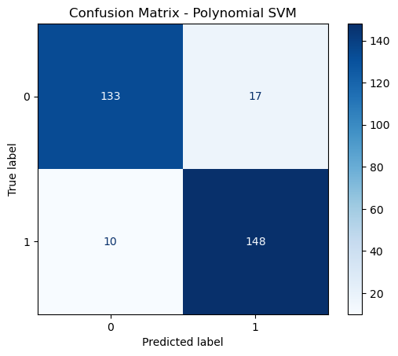

```python
    print("Classification Report:")
    print(classification_report(y_test, y_pred))

    # Plot confusion matrix
    disp = ConfusionMatrixDisplay(confusion_matrix=cm, display_labels=model.classes_)
    disp.plot(cmap=plt.cm.Blues)
    plt.title(f"Confusion Matrix - {name}")
    plt.show()
```

Balanced performance on both classes

High overall accuracy (91%)

No obvious sign of extreme class imbalance or favoring one class

Neural Network Implementation Using Keras

GridSearchCV for best ALPHA and LEARNING RATE

```python
param_grid = {
    'alpha': [0.0001, 0.001, 0.01],
    'learning_rate_init' : [0.001,0.01,0.1]
}
grid_search = GridSearchCV(MLPClassifier(max_iter=1000, random_state=42), param_grid, cv=5, n_jobs=-1, verbose=2, scoring='accuracy')
grid_search.fit(X_train_scaled, y_train)
alpha_best = grid_search.best_params_['alpha']
learning_rate_best = grid_search.best_params_['learning_rate_init']
print(f"\nBest Alpha from GridSearchCV: {alpha_best}")
print(f"\nBest Learning_rate from GridSearchCV: {learning_rate_best}")
```

```
Fitting 5 folds for each of 9 candidates, totalling 45 fits

Best Alpha from GridSearchCV: 0.0001

Best Learning_rate from GridSearchCV: 0.001
```

```python
model = Sequential([
    Dense(64, input_shape=(13,), activation='relu'), #input layer
    Dense(32, activation='relu'),                   #hidden layer
    Dense(2, activation='softmax')                 #output layer
])
```

```python
model.summary()
```

```
Model: "sequential_8"
```

```
┏━━━━━━━━━━━━━━━━━━━━━━━━━━━━━━━━━┳━━━━━━━━━━━━━━━━━━━━━━━━┳━━━━━━━━━━━━━━━┓
┃ Layer (type)                    ┃ Output Shape           ┃       Param # ┃
┡━━━━━━━━━━━━━━━━━━━━━━━━━━━━━━━━━╇━━━━━━━━━━━━━━━━━━━━━━━━╇━━━━━━━━━━━━━━━┩
│ dense_24 (Dense)                │ (None, 64)             │           896 │
├─────────────────────────────────┼────────────────────────┼───────────────┤
│ dense_25 (Dense)                │ (None, 32)             │         2,080 │
├─────────────────────────────────┼────────────────────────┼───────────────┤
│ dense_26 (Dense)                │ (None, 2)              │            66 │
└─────────────────────────────────┴────────────────────────┴───────────────┘
```

```
 Total params: 3,042 (11.88 KB)
```

```
 Trainable params: 3,042 (11.88 KB)
```

```
 Non-trainable params: 0 (0.00 B)
```

preparing the model for training :

which optimizer to use

which loss function to minimize

which evaluation metrics to track during training & validation

```python
model.compile(Adam(learning_rate=learning_rate_best),loss='sparse_categorical_crossentropy', metrics=['accuracy'])
```

Training the model

```python
history = model.fit(X_train_scaled, y_train, batch_size=10, epochs=20, shuffle=True, verbose=2, validation_data=(X_test_scaled, y_test))
```

```
72/72 - 5s - 69ms/step - accuracy: 0.7545 - loss: 0.5214 - val_accuracy: 0.8279 - val_loss: 0.3752
72/72 - 0s - 6ms/step - accuracy: 0.8550 - loss: 0.3506 - val_accuracy: 0.8571 - val_loss: 0.3127
72/72 - 0s - 5ms/step - accuracy: 0.8745 - loss: 0.3003 - val_accuracy: 0.8701 - val_loss: 0.2902
72/72 - 0s - 5ms/step - accuracy: 0.9010 - loss: 0.2691 - val_accuracy: 0.8701 - val_loss: 0.2751
72/72 - 0s - 5ms/step - accuracy: 0.9079 - loss: 0.2399 - val_accuracy: 0.8961 - val_loss: 0.2604
72/72 - 0s - 4ms/step - accuracy: 0.9191 - loss: 0.2151 - val_accuracy: 0.9091 - val_loss: 0.2436
72/72 - 0s - 5ms/step - accuracy: 0.9372 - loss: 0.1926 - val_accuracy: 0.9123 - val_loss: 0.2343
72/72 - 0s - 4ms/step - accuracy: 0.9470 - loss: 0.1671 - val_accuracy: 0.9286 - val_loss: 0.2163
72/72 - 0s - 4ms/step - accuracy: 0.9512 - loss: 0.1515 - val_accuracy: 0.9448 - val_loss: 0.2114
72/72 - 0s - 5ms/step - accuracy: 0.9637 - loss: 0.1285 - val_accuracy: 0.9513 - val_loss: 0.1955
72/72 - 0s - 5ms/step - accuracy: 0.9693 - loss: 0.1109 - val_accuracy: 0.9545 - val_loss: 0.1813
72/72 - 0s - 5ms/step - accuracy: 0.9763 - loss: 0.0998 - val_accuracy: 0.9578 - val_loss: 0.1680
72/72 - 0s - 5ms/step - accuracy: 0.9833 - loss: 0.0917 - val_accuracy: 0.9643 - val_loss: 0.1576
72/72 - 0s - 4ms/step - accuracy: 0.9847 - loss: 0.0752 - val_accuracy: 0.9610 - val_loss: 0.1489
72/72 - 0s - 4ms/step - accuracy: 0.9847 - loss: 0.0689 - val_accuracy: 0.9643 - val_loss: 0.1391
72/72 - 0s - 5ms/step - accuracy: 0.9902 - loss: 0.0585 - val_accuracy: 0.9643 - val_loss: 0.1304
72/72 - 0s - 4ms/step - accuracy: 0.9930 - loss: 0.0514 - val_accuracy: 0.9643 - val_loss: 0.1284
72/72 - 0s - 5ms/step - accuracy: 0.9930 - loss: 0.0445 - val_accuracy: 0.9708 - val_loss: 0.1164
72/72 - 0s - 4ms/step - accuracy: 0.9902 - loss: 0.0405 - val_accuracy: 0.9773 - val_loss: 0.1159
72/72 - 0s - 4ms/step - accuracy: 0.9944 - loss: 0.0360 - val_accuracy: 0.9773 - val_loss: 0.1129
```

```python
test_loss, test_accuracy = model.evaluate(X_test_scaled, y_test, verbose=0)
print(f'Test Loss: {test_loss:.4f}')
print(f'Test Accuracy: {test_accuracy:.4f}')
```

```
Test Loss: 0.1129
Test Accuracy: 0.9773
```

```python
# Get predictions
y_pred_probs = model.predict(X_test_scaled)
y_pred = y_pred_probs.argmax(axis=1)

# Classification report
print(classification_report(y_test, y_pred))

# Confusion matrix
conf_matrix = confusion_matrix(y_test, y_pred)
print('Confusion Matrix:')
print(conf_matrix)
```

```
10/10 ━━━━━━━━━━━━━━━━━━━━ 0s 10ms/step
              precision    recall  f1-score   support

           0       0.97      0.98      0.98       150
           1       0.98      0.97      0.98       158

    accuracy                           0.98       308
   macro avg       0.98      0.98      0.98       308
weighted avg       0.98      0.98      0.98       308

Confusion Matrix:
[[147   3]
 [  4 154]]
```

The neural network outperforms all SVM models across every metric — accuracy, precision, recall, and F1-score. It makes much fewer mistakes (7 vs 27 errors).

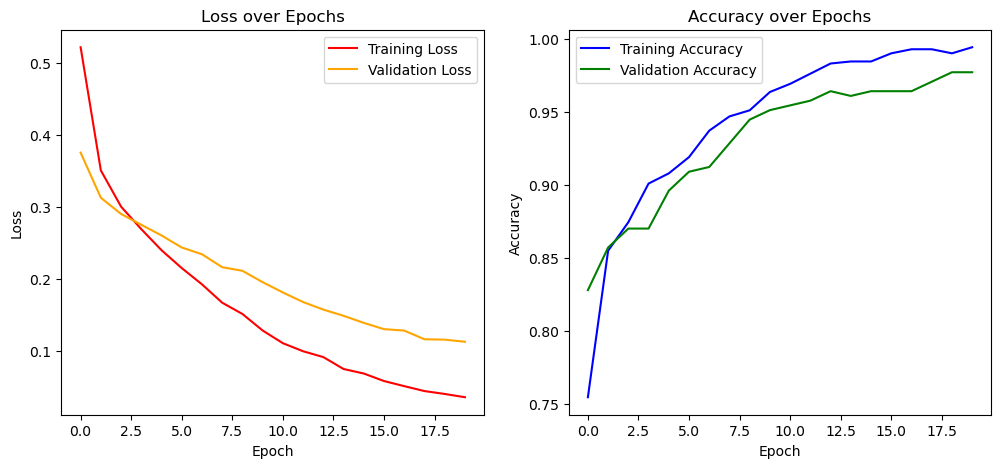

```python
plt.figure(figsize=(12, 5))

# Loss plot
plt.subplot(1, 2, 1)
plt.plot(history.history['loss'], label='Training Loss', color='red')
plt.plot(history.history['val_loss'], label='Validation Loss', color='orange')
plt.title('Loss over Epochs')
plt.xlabel('Epoch')
plt.ylabel('Loss')
plt.legend()

# Accuracy plot
plt.subplot(1, 2, 2)
plt.plot(history.history['accuracy'], label='Training Accuracy', color='blue')
plt.plot(history.history['val_accuracy'], label='Validation Accuracy', color='green')
plt.title('Accuracy over Epochs')
plt.xlabel('Epoch')
plt.ylabel('Accuracy')
plt.legend()

plt.show()
```

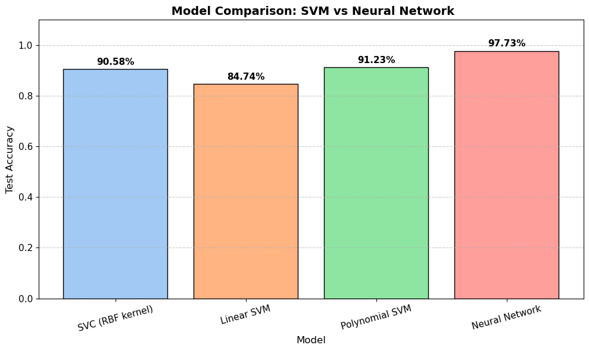

```python
nn_test_accuracy = test_accuracy  # from model.evaluate

svm_accuracies = {}
for name, svm_model in svm_models.items():
    svm_model.fit(X_train_scaled, y_train)
    y_pred = svm_model.predict(X_test_scaled)
    acc = accuracy_score(y_test, y_pred)
    svm_accuracies[name] = acc

# Step 2: Combine all into one dictionary
all_accuracies = svm_accuracies.copy()
all_accuracies['Neural Network'] = nn_test_accuracy




plt.figure(figsize=(10, 6))
colors = sns.color_palette('pastel')[0:4]
bars = plt.bar(all_accuracies.keys(), all_accuracies.values(), color=colors, edgecolor='black')

# Step 4: Add accuracy labels on top (in %)
for bar in bars:
    height = bar.get_height()
    plt.text(bar.get_x() + bar.get_width() / 2,
             height + 0.01,
             f"{height * 100:.2f}%",
             ha='center',
             va='bottom',
             fontsize=11,
             fontweight='bold')

plt.ylim(0, 1.1)
plt.grid(axis='y', linestyle='--', alpha=0.7)
plt.xlabel('Model', fontsize=12)
plt.ylabel('Test Accuracy', fontsize=12)
plt.title(' Model Comparison: SVM vs Neural Network', fontsize=14, fontweight='bold')
plt.xticks(rotation=15, fontsize=11)
plt.yticks(fontsize=11)
plt.tight_layout()
plt.show()
```

Summary of Key Findings:

Neural Network is the best-performing model with the highest accuracy (97.73%) and a relatively low test loss (0.1129). It seems to generalize well, providing excellent results.

Linear SVM performs the worst among the three, with an accuracy of 84.74%. It’s not well-suited for datasets with non-linear relationships, which is likely why its performance is lower.